# Case Study 1 - Gruppe 12

# Q1

## Ratio of Fibonacci numbers

The Fibonacci sequence is a series of numbers where a number is the addition of the last two numbers, starting with 0 and 1.

## For and While functions

Two R functions were implemented to calculate the sequence of ratios of consecutive Fibonacci numbers for a given number of terms. The first function uses a `for` loop, while the second function uses a `while` loop.

```r
# Using for loop
fib_ratio_for <- function(n) {
  fib <- c(0, 1)
  ratio <- numeric(n)
  for(i in 1:n) {
    fib <- c(fib, sum(tail(fib, 2)))
    ratio[i] <- fib[i+2] / fib[i+1]
  }
  return(ratio)
}

# Using while loop
fib_ratio_while <- function(n) {
  fib <- c(0, 1)
  ratio <- numeric(n)
  i <- 1
  while(i <= n) {
    fib <- c(fib, sum(tail(fib, 2)))
    ratio[i] <- fib[i+2] / fib[i+1]
    i <- i + 1
  }
  return(ratio)
}
```

## The result of benchmark two functions

```r
if (!require(microbenchmark)) install.packages('microbenchmark')
# Benchmark the functions
library(microbenchmark)
n <- 200
microbenchmark(fib_ratio_for(n), fib_ratio_while(n), times = 100L)
```

```
## Unit: milliseconds
##                expr    min      lq     mean  median      uq     max neval
##    fib_ratio_for(n) 1.1596 1.22605 1.910005 1.38620 1.88875 27.1820   100
##  fib_ratio_while(n) 1.1682 1.23000 1.728527 1.47485 1.90380 11.2299   100
```

## Result of the Plot

The sequence of ratios was plotted for n = 100 using the ggplot2 package in R. The plot showed that the sequence starts to converge quickly, within the first 10 terms. The sequence converges to the golden ratio, approximately 1.61803398875. This was verified by checking the last few terms of the sequence.

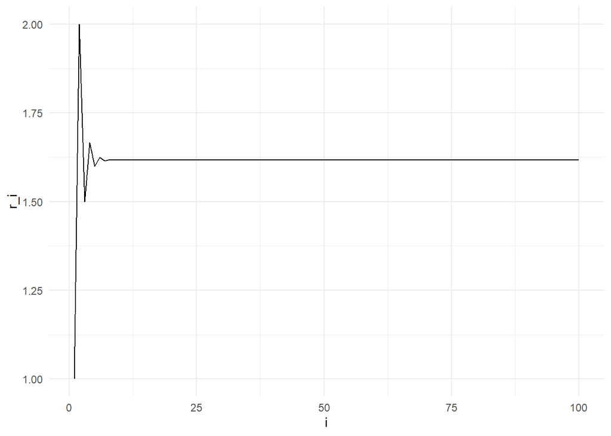

```r
if (!require(ggplot2)) install.packages('ggplot2')
# Plot the sequence
library(ggplot2)
n <- 100
ratio <- fib_ratio_for(n)
df <- data.frame(x = 1:n, y = ratio)
ggplot(df, aes(x=x, y=y)) + geom_line() + theme_minimal() + labs(x = "i", y = "r_i")
```

```r
tail(ratio, 10)
```

```
##  [1] 1.618034 1.618034 1.618034 1.618034 1.618034 1.618034 1.618034 1.618034
##  [9] 1.618034 1.618034
```